# IUCN + spp crossing - PCA & MCA clean

```r
library(tidyverse)
library(terra)
library(sf)
library(rnaturalearth)
library(here)
library(iucnredlist) ### remotes::install_github("IUCN-UK/iucnredlist")
library(taxize)
library(janitor)
library(ggfortify)
library(cowplot)
```

This document is a streamlined version of 6_combine_sppxborder_bird_traits.qmd

```r
# Functions
source(here("common_fxns.R"))
```

```r
# Read in Lawler data
spp_mapfiles <- list.files(here_anx('/data_lawler_2020/species_projections'),
                           full.names = TRUE, recursive = TRUE, pattern = '.tif')
spp_all_df <- data.frame(f = spp_mapfiles,
                         spp = basename(spp_mapfiles) %>%
                           str_remove('(_gf85|_in85|_mc85|_bias).+') %>%
                           str_replace_all('_', ' '),
                         tax = basename(dirname(spp_mapfiles)))
```

```r
# Read in AVONET dataset (reading in BirdLife tab, which should match with IUCN names)
avonet <- read_csv(here("data-laa", "AVONET-birdlife-tab-supplementary-dataset-1.csv")) %>%
  clean_names()
```

```r
# Filter for just Lawler birds
birds_all_df <- spp_all_df %>%
  filter(tax == "Birds")
```

```r
birds_all <- birds_all_df %>%
  group_by(spp, tax) %>%
  summarize(files = n())
```

## Gather maps and aggregate

Following the method in 2_combine_spp_scenarios.qmd: For all the Lawler birds species (301) gather all future scenario maps and aggregate, summing and dividing by 3 to make a “probability” map for future distributions, and crop to just the lower 48 US states (and a little Canada and Mexico). Then crop the historical maps to the same extent.

### Aggregate future projections

For each species in the sample, aggregate the three future scenarios into a single map. Crop to the lower continental US states.

```r
### set up extent for continental US
us_extent <- ext(c(xmin = -130, xmax = -65, ymin = 23, ymax = 50))

### Aggregate over the vector of species names
spp_vec <- birds_all_df$spp %>% unique()

future_rast <- lapply(spp_vec, FUN = agg_scenario, df = birds_all_df) %>%
  setNames(spp_vec) %>%
  rast()

x <- future_rast[[1]]
#plot(x, main = names(future_rast)[1])
```

### crop historical maps

```r
hist_rast <- lapply(spp_vec, FUN = agg_scenario, df = birds_all_df,
                    scenario = 'historical') %>%
  setNames(spp_vec) %>%
  rast()

x <- hist_rast[[1]]
#plot(x, main = names(hist_rast)[1])
```

## Generate jurisdiction map

Let’s generate a simple jurisdiction map - US states, and Canada and Mexico.

```r
states_sf <- ne_states(returnclass = 'sf', country = c('Mexico', 'Canada', 'United States of America'))

state_id_df <- states_sf %>%
  st_drop_geometry() %>%
  mutate(juris = ifelse(adm0_a3 == 'USA', name, admin)) %>%
  select(id = gn_id, juris)
### plot(states_sf %>% select(iso_a2))
states_rast <- rasterize(states_sf, hist_rast, field = 'gn_id')
#plot(states_rast)
```

## Rough pass at classification?

For each spp let’s create a dataframe of jurisdictions and cell values…

```r
state_spp_list <- lapply(spp_vec, FUN = extract_jurisdictions,
                         future_r = future_rast,
                         hist_r = hist_rast,
                         juris_r = states_rast) %>%
  setNames(spp_vec) %>%
  bind_rows(.id = 'spp') %>%
  left_join(state_id_df, by = 'id') %>%
  ### note, Canada and Mexico have multiple jurisdictions (provinces and states)
  ### so sum up all those instances
  group_by(spp, juris) %>%
  summarize(n_historical = sum(n_historical),
            n_future = sum(n_future),
            .groups = 'drop')
```

## Interpret results

Interpret historical and future cell counts into entry/exit/no presence/continued presence. NOTE: probably would want to throw a threshold on the cell counts, like at least 10 cells to actually register…

Let’s filter to the birds that easly merge with the Avonet dataset (270)

```r
# See how well the Avonet trait data merges in
# 270 of 301 have matches - could work with these species for now since they should be able to match wiht IUCN
birds_avonet <- left_join(birds_all, (avonet %>% rename(spp = species1)))

lawler_avvonet_birds <- birds_avonet %>%
  drop_na(sequence)

lawler_avvonet_birds_vec <- lawler_avvonet_birds$spp
```

```r
all_juris_df <- state_spp_list %>%
  filter(spp %in% lawler_avvonet_birds_vec) %>%
  group_by(spp) %>%
  mutate(range_historical = sum(n_historical),
         range_future = sum(n_future),
         range_ratio = range_future/range_historical,
         prec_historical = 100*n_historical/sum(n_historical),
         prec_future = 100*n_future/sum(n_future),
         prec_pt_change = prec_future - prec_historical) %>%
  mutate(status = case_when(n_historical == 0 &  n_future > 0 ~ 'entry into new',
                            n_historical > 0  & n_future == 0 ~ 'exit from historical',
                            n_historical == 0 & n_future == 0 ~ 'no presence',
                            TRUE ~ 'continued presence')) %>%
  ungroup()

all_juris_df$status %>% table()
```

```
.
  continued presence       entry into new exit from historical
                2606                  354                 1968
         no presence
                8842
```

```r
entry_exit <- all_juris_df %>%
  filter(status %in% c("entry into new", "exit from historical")) #%>%
  #separate(spp, into = c("genus", "species"), sep = " ", remove = FALSE) %>%
  #rename(scientific_name = spp)
```

```r
# Just focusing on country level jurisdiction movement for now
entry_exit_ca_mx <- entry_exit %>%
  mutate(country = case_when(juris == "Canada" ~ "Canada",
                             juris == "Mexico" ~ "Mexico",
                             TRUE ~ "United States")) %>%
  filter(country != "United States")
```

# Test out Canada birds that don’t migrate and assign binary variable for diet type

```r
birds_all_juris_avonet <- left_join(all_juris_df, (avonet %>% rename(spp = species1)))
```

```r
# Canada data
ca_data <- birds_all_juris_avonet %>%
  filter(juris == "Canada") %>%
  filter(status != "no presence")
```

```r
ca_sed <- ca_data %>%
  # Migration == 1 is sedentary lifestyle
  filter(migration == 1) %>%
  mutate(trophic_level = tolower(trophic_level)) %>%
  mutate(trophic_level_value =1) %>%
  # binary variable for trophic level (carnivore, herbivore, omnivore, scavenger)
  pivot_wider(names_from = trophic_level,
              values_from = trophic_level_value,
              values_fill = 0)
```

```r
# Canada sedentary - (historical vs. future)
ca_sed_hist <- ca_sed %>%
  filter(status != "entry into new") %>%
  mutate(hist_or_future = "historical")

ca_sed_future <- ca_sed%>%
  filter(status != "exit from historical") %>%
  mutate(hist_or_future = "future")

ca_sed_hist_future <- rbind(ca_sed_hist, ca_sed_future)
```

```r
# Prep for PCA
ca_pca_sed_logged <- ca_sed_hist_future %>%
  select(c(spp, hist_or_future, beak_length_culmen, tarsus_length, wing_length, hand_wing_index, tail_length, mass, carnivore, herbivore, omnivore, scavenger)) %>%
  # log transform in preparation for PCA
  mutate(across(c(beak_length_culmen:mass), log))
```

```r
# centered at zero (center = TRUE) and z-transformed (scale = TRUE)
pca_ca_sed<- prcomp(ca_pca_sed_logged[3:12], center = TRUE, scale = TRUE )
```

```r
summary(pca_ca_sed)
```

```
Importance of components:
                          PC1    PC2    PC3     PC4     PC5     PC6     PC7
Standard deviation     2.0820 1.3533 1.2401 0.93604 0.87685 0.55254 0.50312
Proportion of Variance 0.4335 0.1831 0.1538 0.08762 0.07689 0.03053 0.02531
Cumulative Proportion  0.4335 0.6166 0.7704 0.85802 0.93490 0.96543 0.99075
                           PC8     PC9      PC10
Standard deviation     0.26945 0.14117 1.774e-16
Proportion of Variance 0.00726 0.00199 0.000e+00
Cumulative Proportion  0.99801 1.00000 1.000e+00
```

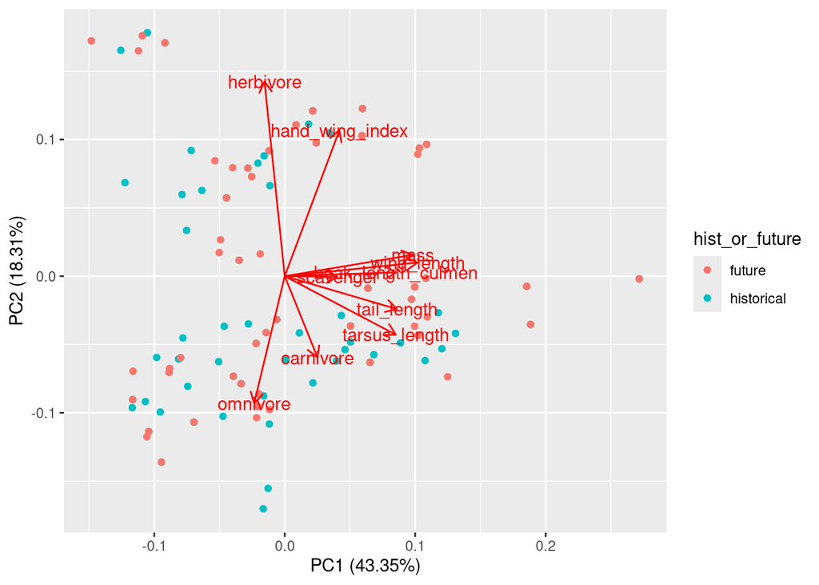

```r
autoplot(pca_ca_sed,
         data = ca_pca_sed_logged,
         color = "hist_or_future",
         loadings = TRUE,
         loadings.label = TRUE)
```

```r
# Convert results into data frame
ca_sed_pca_df <- as.data.frame(pca_ca_sed$x) %>%
  mutate(spp = ca_pca_sed_logged$spp,
         hist_or_future = ca_pca_sed_logged$hist_or_future)
```

```r
ca_sed_pca_hull <- ca_sed_pca_df %>%
  arrange(hist_or_future, PC1, PC2) %>%
  group_by(hist_or_future) %>%
  slice(chull(PC1, PC2))

ca_sed_pca_hull_32 <- ca_sed_pca_df %>%
  arrange(hist_or_future, PC3, PC2) %>%
  group_by(hist_or_future) %>%
  slice(chull(PC3, PC2))
```

```r
# Scale factor for loadings
ca_sed_scale <- min(max(abs(ca_sed_pca_df$PC1)), max(abs(ca_sed_pca_df$PC2))) /
  max(abs(pca_ca_sed$rotation[, 1:2]))

# Get rotation dataframe for loadings (arrows)
ca_sed_rot_df <- data.frame(pca_ca_sed$rotation %>% round(4) *
                                 ca_sed_scale) %>%
  mutate(query = rownames(.))
```

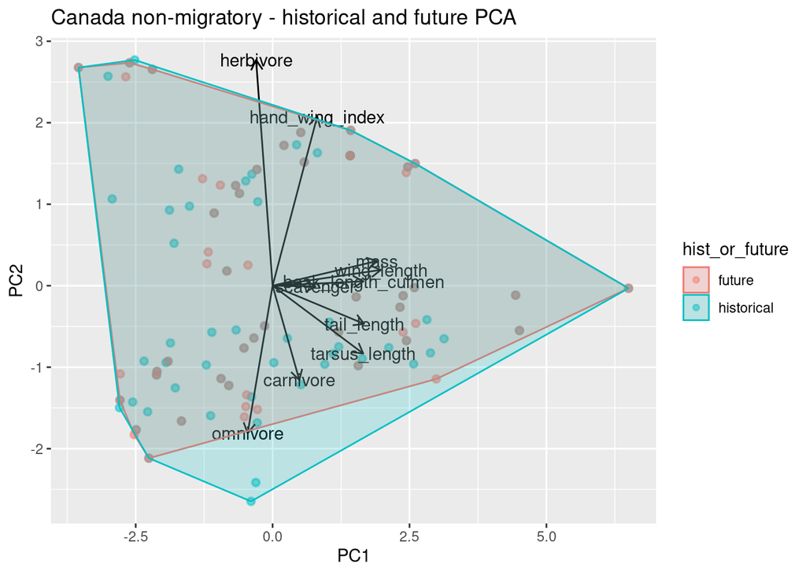

```r
ggplot(ca_sed_pca_df, aes(x = PC1, y = PC2)) +
  geom_point(aes(color = hist_or_future,
                 fill = hist_or_future,
                 stroke = 1), alpha = 0.5) +
  geom_segment(data = ca_sed_rot_df, x = 0, y = 0,
               aes(xend = PC1, yend = PC2),
               arrow = arrow(length = unit(.1, 'inches'))) +
  geom_text(data = ca_sed_rot_df, aes(label = query))+
  geom_polygon(data = ca_sed_pca_hull,
               aes(x = PC1, y = PC2,
                   color = hist_or_future, fill = hist_or_future), alpha = 0.2) +
  labs(title = "Canada non-migratory - historical and future PCA")
```

```r
ca_sed_gns_spp <- ca_sed_pca_df %>%
  separate(spp, into = c("genus", "species"), sep = " ", remove = FALSE) %>%
  rename(scientific_name = spp) %>%
  group_by(scientific_name, genus, species) %>%
  summarise(count = n()) %>%
  ungroup()
```

# Add in IUCN info

```r
api_key <- Sys.getenv("IUCN_API_KEY") ### usethis::edit_r_environ() to add key to R environment file
api <- init_api(api_key)
```

```r
# Pull the genus and species names
ca_sed_gns <- ca_sed_gns_spp$genus
ca_sed_species <- ca_sed_gns_spp$species
```

```r
# Amazilia beryllina [2] should be Saucerottia beryllina
# Amazilia violiceps [3] should be Leucolia violiceps
# Falcipennis canadensis [36] should be Canachites canadensis
ca_sed_gns[2] <- "Saucerottia"
ca_sed_gns[3] <- "Leucolia"
ca_sed_gns[36] <- "Canachites"
```

```r
# Loop through function, save as list
ca_sed_iucn_id_list <- list()
for(i in 1:length(ca_sed_species)){
  test <- iucn_id(api, ca_sed_gns[i], ca_sed_species[i])
  ca_sed_iucn_id_list[[i]] <- test
}
```

```r
ca_sed_id_vector <- unlist(ca_sed_iucn_id_list)
```

```r
# Run the assessment numbers collected from the iucn_id function
# 54 unique assessment IDs (have species repeaeted in historic and future)
ca_sed_id_data <- assessment_data_many(api, ca_sed_id_vector, wait_time = 0.5)
```

```r
# Extract the IUCN status from all the sample species (or any other variable of interest)
# Run element_names() to see what you can extract
ca_sed_names <- extract_element(ca_sed_id_data, "taxon")
ca_sed_status <- extract_element(ca_sed_id_data, "red_list_category")
ca_sed_trends <- extract_element(ca_sed_id_data, "population_trend")

ca_sed_names_status <- left_join(ca_sed_names, ca_sed_status, by = "assessment_id")
ca_sed_names_status_trends <- left_join(ca_sed_names_status, ca_sed_trends,
                                           by = "assessment_id") %>%
  mutate(threatened = case_when(description.x %in% c("Least Concern", "Near Threatened") ~ "not threatened",
                               TRUE ~ "threatened"))
```

```r
ca_sed_iucn_clean <- ca_sed_names_status_trends %>%
  dplyr::select(scientific_name, description.x, description.y, threatened) %>%
  rename(spp = scientific_name,
         iucn_status = description.x,
         iucn_trend = description.y) %>%
  # return scientific names to Lawler dataset
  mutate(spp = case_when(spp == "Saucerottia beryllina" ~ "Amazilia beryllina",
                         spp == "Leucolia violiceps" ~"Amazilia violiceps",
                         spp == "Canachites canadensis" ~ "Falcipennis canadensis",
                         TRUE ~ spp))
```

```r
ca_sed_iucn_count <- left_join(ca_sed_hist_future, ca_sed_iucn_clean) %>%
  group_by(hist_or_future, threatened) %>%
  summarize(n_carnivore = sum(carnivore),
            n_herbivore = sum(herbivore),
            n_omnivore = sum(omnivore),
            n_scavenger = sum(scavenger),
            n_total = n()) %>%
  ungroup()
```

```r
ca_sed_pca_df_iucn <- left_join(ca_sed_pca_df, ca_sed_iucn_clean)
```

```r
sed_p12 <- ggplot(ca_sed_pca_df_iucn, aes(x = PC1, y = PC2)) +
  geom_point(aes(color = hist_or_future,
                 shape = threatened), size = 2.5, alpha = 0.5) +
  geom_segment(data = ca_sed_rot_df, x = 0, y = 0,
               aes(xend = PC1, yend = PC2),
               arrow = arrow(length = unit(.1, 'inches'))) +
  geom_text(data = ca_sed_rot_df, aes(label = query))+
  geom_polygon(data = ca_sed_pca_hull,
               aes(x = PC1, y = PC2,
                   color = hist_or_future, fill = hist_or_future), alpha = 0.2) +
  labs(title = "Canada non-migratory")
```

```r
sed_p32 <- ggplot(ca_sed_pca_df_iucn, aes(x = PC3, y = PC2)) +
  geom_point(aes(color = hist_or_future,
                 shape = threatened), size = 2.5, alpha = 0.5) +
  geom_segment(data = ca_sed_rot_df, x = 0, y = 0,
               aes(xend = PC3, yend = PC2),
               arrow = arrow(length = unit(.1, 'inches'))) +
  geom_text(data = ca_sed_rot_df, aes(label = query))+
  geom_polygon(data = ca_sed_pca_hull_32,
               aes(x = PC3, y = PC2,
                   color = hist_or_future, fill = hist_or_future), alpha = 0.2) +
  labs(title = "")
```

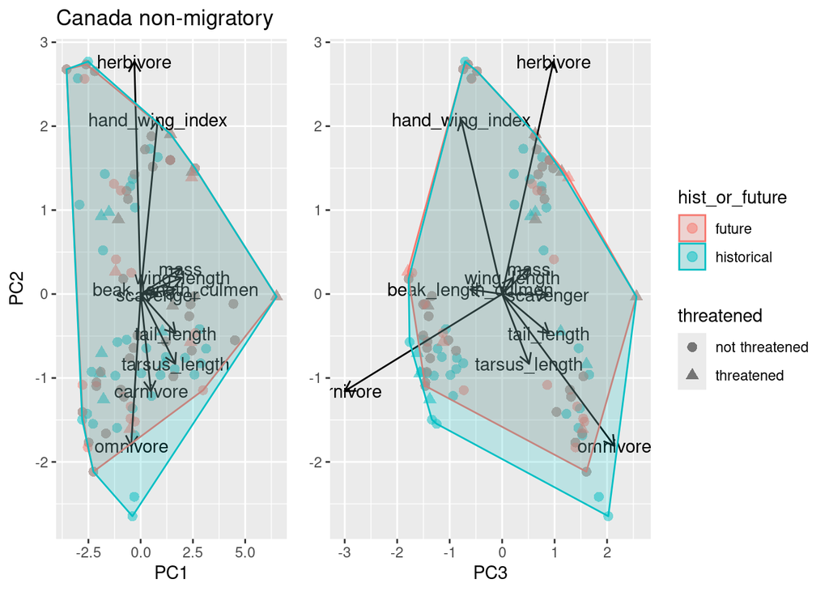

```r
plot_grid(sed_p12 + theme(legend.position = 'none'), sed_p32 + theme(axis.title.y = element_blank()), rel_widths = c(2, 3.6))
```

# Test out using categorical variables in MCA

```r
library(MASS)
```

```r
# Filter the Canada sedentary birds so that it is just the categorical variables
```

```r
# Canada data
ca_data <- birds_all_juris_avonet %>%
  filter(juris == "Canada") %>%
  filter(status != "no presence")
```

```r
ca_sed_cat <- ca_data %>%
  # Migration == 1 is sedentary lifestyle
  filter(migration == 1) %>%
  # categorical variables include habitat, tropic niche, and lifestyle
  dplyr::select(spp, habitat, trophic_niche, primary_lifestyle)

# Add whether spp are historic or future
ca_sed_cat_hist_fut <- left_join(ca_sed_cat,
                                 (ca_sed_hist_future %>%
                                    dplyr::select(spp, hist_or_future)))
```

```r
# Create dataframe of factors (required for MASS:mca)
ca_sed_mca_prep <- ca_sed_cat_hist_fut[2:4] %>%
  lapply(., as.factor) %>%
  as.data.frame()
```

```r
# Number of categories per variable
cats = apply(ca_sed_mca_prep, 2, function(x) nlevels(as.factor(x)))
cats
```

```
          habitat     trophic_niche primary_lifestyle
                9                10                 5
```

```r
# MCA
ca_sed_mca <- mca(ca_sed_mca_prep)
```

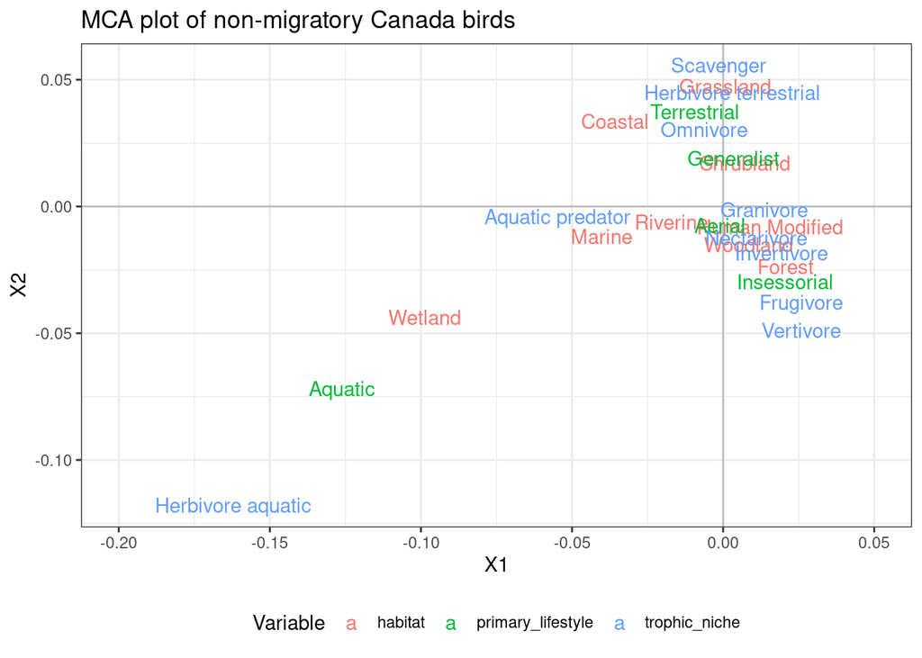

```r
# Test out plotting
# Variable coordinates (adjectives are the columns (cs))
ca_sed_mca_var_df <- data.frame(ca_sed_mca$cs, Variable = rep(names(cats), cats),
                                Variable_value = (rownames(ca_sed_mca$cs))) %>%
  mutate(Variable_value = sub('.*\\.', '', Variable_value))

# Observation coordinates (individual observations are the rows (rs))
ca_sed_mca_obs_df <- data.frame(ca_sed_mca$rs) %>%
  mutate(hist_or_future = ca_sed_hist_future$hist_or_future)

# MCA plot
ggplot(data = ca_sed_mca_var_df, aes(x = X1, y = X2, label = Variable_value)) +
  geom_hline(yintercept = 0, color = "gray") +
  geom_vline(xintercept = 0, color = "gray") +
  geom_text(aes(color = Variable)) +
  ggtitle("MCA plot of non-migratory Canada birds") +
  scale_x_continuous(limits = c(-0.20, 0.05)) +
  theme_bw() +
  theme(legend.position = "bottom")
```

```r
ca_sed_mca_hull <- ca_sed_mca_obs_df %>%
  arrange(hist_or_future, X1, X2) %>%
  group_by(hist_or_future) %>%
  slice(chull(X1, X2))
```

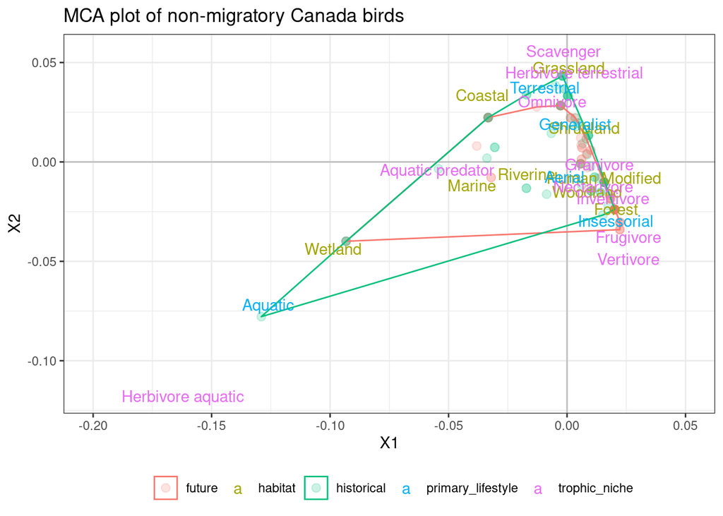

```r
ggplot(data = ca_sed_mca_obs_df, aes(x = X1, y = X2)) +
  geom_hline(yintercept = 0, color = "gray") +
  geom_vline(xintercept = 0, color = "gray") +
  geom_point(aes(color = hist_or_future), alpha = 0.2, size = 2.5) +
  geom_polygon(data = ca_sed_mca_hull,
               aes(x = X1, y = X2,
                   color = hist_or_future), alpha = 0) +
  geom_text(data = ca_sed_mca_var_df,
            aes(x = X1, y = X2,
                label = Variable_value, color = Variable)) +
  scale_x_continuous(limits = c(-0.20, 0.05)) +
  labs(title = "MCA plot of non-migratory Canada birds",
       fill = "",
       color = "") +
  theme_bw() +
   theme(legend.position = "bottom")
```